# Positive but Not Completely Positive Maps (PnCP Maps)

Part I: PnCP Maps as Entanglement Criteria

quantum-information-theory

This series of posts is supposed to provide a report on a research project I did in the first year of my master’s, under [Peter Brown](https://peterjbrown519.github.io/)’s supervision. I will also try to include some more recent relevant results that I have learned about since then.

Author

Ali Almasi

Published

June 25, 2025

**Enhancing Readability for Dyslexic Readers**

It’s unfortunate that there aren’t many good open-source fonts designed specifically for dyslexic readers. However, there’s a helpful [Chrome extension](https://chromewebstore.google.com/detail/opendyslexic-for-chrome/cdnapgfjopgaggbmfgbiinmmbdcglnam?pli=1) that can change the font of the text you read online, making it easier to follow.

## 1 PnCP Maps: What?

Those who are familiar with quantum information theory may remember the notion of *[complete positivity](https://en.wikipedia.org/wiki/Completely_positive_map)* from the definition of [quantum channels](https://en.wikipedia.org/wiki/Quantum_channel). A necessary condition for a map to be a quantum channel is to preserve [semidefinite positivity](https://en.wikipedia.org/wiki/Definite_matrix) in a strong sense, that is, positivity should be preserved even when the map is applied partially to a part of a larger system. This is much stronger than just preserving positivity, which is what *positive maps* do.

A map $\Phi: \mathcal{L}(\mathcal{H}_A)\rightarrow \mathcal{L}(\mathcal{H}_B)$ is said to be positive, if for any $\rho \in \mathcal{L}(\mathcal{H}_A)$ with $\rho \succeq 0$, $\Phi(\rho) \succeq 0$. These maps are not necessarily *physical*, in the sense that they don’t necessarily correspond to physical processes. Nonetheless, not only do they have a rich theory from a mathematical perspective, they also have important applications in quantum information theory. In particular, they are useful for detecting entanglement!

## 2 PnCP Maps: Why?

Deciding whether a bipartite quantum state is separable or entangled in the case of pure states is quite easy. Here, by *easy* I mean there exists an algorithm running in polynomial time in dimensions of the Hilbert spaces involved that does the job.[^1] However, when it comes to [mixed states](https://en.wikipedia.org/wiki/Quantum_state#Mixed_states), the problem becomes [NP-hard](https://en.wikipedia.org/wiki/NP-hardness) [Ghar10; Gurv03]. It might be good to recall that the notion of *separability* in the mixed state formalism is slightly different from its pure state counterpart. In the mixed state formalism, we have

<sup>1</sup> In fact, this task is not harder than finding the [singular value decomposition](https://en.wikipedia.org/wiki/Singular_value_decomposition) of a matrix (Why?).

[Ghar10]

Gharibian, Sevag: Strong NP-hardness of the quantum separability problem. In: *Quantum Information & Computation* vol. 10, Rinton Press, Incorporated Paramus, NJ (2010), Nr. 3, pp. 343–360

[Gurv03]

Gurvits, Leonid: [Classical deterministic complexity of edmonds’ problem and quantum entanglement](https://doi.org/10.1145/780542.780545). In: *Proceedings of the thirty-fifth annual ACM symposium on theory of computing*, *STOC ’03*. New York, NY, USA : Association for Computing Machinery, 2003 — ISBN 1581136749, pp. 10–19

- **product states**, which are of the form $\rho_{AB} = \rho_A \otimes \rho_B$ for some $\rho_A \in \mathcal{L}(\mathcal{H}_A)$ and $\rho_B \in \mathcal{L}(\mathcal{H}_B)$,
- **separable states**, which are convex combinations of product states, i.e., $\rho_{AB} = \sum_i p_i \rho_A^i \otimes \rho_B^i$ for some $p_i \geq 0$ and $\sum_i p_i = 1$, and
- **entangled states**, which are those that are not separable.

In the following, we will denote the set of separable states over a bipartite Hilbert space $\mathcal{L}(\mathbb{C}^{d_A} \otimes \mathbb{C}^{d_B})$ by $\mathsf{SEP}_{d_A, d_B}$ (I often omit writing the dimensions when they are clear from the context).

Not only deciding whether a state is separable or not is *asymptotically* hard, but even in fixed dimensions, it is not generally known how to efficiently solve it. In some cases, we have efficient algorithms, but in general, we don’t. Instead, people have developed several *necessary conditions* for separability, which are sometimes called *entanglement criteria* (see e.g. [GüTó09]). Even though these criteria are not necessarily sufficient in all cases, they can still be useful.

[GüTó09]

Gühne, Otfried ; Tóth, Géza: [Entanglement detection](https://doi.org/10.1016/j.physrep.2009.02.004). In: *Physics Reports* vol. 474 (2009), Nr. 1, pp. 1–75

[PlVi14]

Plenio, Martin B. ; Virmani, Shashank S.: [An introduction to entanglement theory](https://doi.org/10.1007/978-3-319-04063-9_8). In: Andersson, E. ; Öhberg, P. (eds.): *Quantum information and coherence*. Cham : Springer International Publishing, 2014 — ISBN 978-3-319-04063-9, pp. 173–209

[VePl98]

Vedral, Vlatko ; Plenio, Martin B: Entanglement measures and purification procedures. In: *Physical Review A* vol. 57, APS (1998), Nr. 3, p. 1619

To see this, let’s consider an example of a scenario where we would like to decide separability: *measuring entanglement*. There are several approaches to define a *measure of entanglement* (see e.g. [PlVi14]). Here is one of them, called the *relative entropy of entanglement* [VePl98]: for a bipartite quantum state $\rho_{AB}$, the relative entropy of entanglement is defined as
$$E_R\left(\rho_{A B}\right) := \min _{\sigma_{A B}\in \mathsf{SEP}} S\left(\rho_{A B} \| \sigma_{A B}\right),$$
where $S\left(\cdot \| \cdot\right)$ is the [quantum relative entropy](https://en.wikipedia.org/wiki/Quantum_relative_entropy). As you can see, in the above optimization problem, checking the feasibility of a solution is not easy, as was discussed. However, having a necessary condition for separability, we can relax the above optimization to another one, whose optimal solution is then a lower bound on the relative entropy of entanglement.

The above example also motivates comparing entanglement criteria to each other, to see which one provides a better approximation to $\mathsf{SEP}$, and thus for example, a better relaxation and a better lower bound for the aforementioned optimization problem. As I mentioned earlier, and we will see that in more detail later, positive but not completely positive can be used as entanglement criteria. One of the most famous entanglement criteria, the *[PPT criterion](https://en.wikipedia.org/wiki/Peres%E2%80%93Horodecki_criterion)*, is an example of such criteria. Let’s take a closer look and see how it works.

## 3 PPT

PPT stands for *positive partial transpose*. Let $\rho_{AB} \in \mathcal{L}(\mathbb{C}^{d_A} \otimes \mathbb{C}^{d_B})$ be a bipartite quantum state. The partial transpose of $\rho_{AB}$ (without loss of generality, with respect to the second subsystem) is defined as
$$\rho_{AB}^{T_B} := \left(\mathcal{I}_A \otimes \mathsf{T}_B\right)(\rho_{AB}),$$
where $\mathcal{I}_A$ is the identity map on the first subsystem and $\mathsf{T}_B$ is the transposition map on the second subsystem. For example, if $\rho_{AB} = \begin{bmatrix} A & B \\ C & D \end{bmatrix}$, where $A,B,C,D \in \mathcal{L}(\mathbb{C}^{d_B})$, then $\rho_{AB}^{\mathsf{T}_B} = \begin{bmatrix} A^\mathsf{T} & B^\mathsf{T} \\ C^\mathsf{T} & D^\mathsf{T} \end{bmatrix}$. The PPT criterion states that

**PPT Criterion**

If $\rho_{AB}$ is separable, then $\rho_{AB}^{\mathsf{T}_B}$ is positive semidefinite. In other words, if $\rho_{AB}^{\mathsf{T}_B}$ is not positive semidefinite, then $\rho_{AB}$ is entangled.

As you see, the PPT criterion is a necessary condition for separability. Are there bipartite entangled states that satisfy the PPT criterion? In the case of bipartite systems of local dimensions $ (d_A, d_B) = (2,2) , (2,3), (3,2)$, then the answer is no. In these dimensions, one can show that the PPT criterion is also sufficient for separability. In other dimensions, however, we can prove that the PPT criterion is not sufficient [HoHoHo01; Woro76].

[HoHoHo01]

Horodecki, Michał ; Horodecki, Paweł ; Horodecki, Ryszard: Separability of $n$-particle mixed states: Necessary and sufficient conditions in terms of linear maps. In: *Physics Letters A* vol. 283, Elsevier (2001), Nr. 1-2, pp. 1–7

[Woro76]

Woronowicz, S. L.: Positive maps of low dimensional matrix algebras. In: *Reports on Mathematical Physics* vol. 10 (1976), Nr. 2, pp. 165–183

## 4 PnCP Maps: How?

Why does the transposition map provide such a criterion? In fact, it is not only the transposition map that does this, but any PnCP map does. The proof is fairly simple. Suppose that we have a bipartite system consisting of two subsystems $A$ and $B$, with the associated Hilbert spaces $\mathcal{H}_A$ and $\mathcal{H}_B$. Let $\Phi: \mathcal{L}(\mathcal{H}_B)\rightarrow \mathcal{L}(\mathcal{H}_A)$ be a positive but not completely positive map. We define the set of all states that are positive under partial application of $\Phi$ as
$$\mathsf{PP}\Phi:=\{\rho_{AB}\in \mathsf{D}~:~ (\mathcal{I}_A\otimes \Phi)\rho_{AB}\succeq 0\},$$
where $\mathsf{D}$ is the set of all density operators on $\mathcal{H}_A \otimes \mathcal{H}_B$.

Let us first show that $\mathsf{SEP} \subseteq \mathsf{PP}\Phi$. For any separable state $\rho = \sum_{i} p_i\sigma_i\otimes \tau_i$,
$$(\mathcal{I}_A\otimes \Phi)\rho = \sum_{i} p_i \sigma_i\otimes \Phi(\tau_i) \succeq 0 ,$$
where the inequality holds because $\Phi$ is positive. Thus $\mathsf{SEP}$ is contained in $\mathsf{PP}\Phi$. This shows that if $\Phi$ is a positive map, it provides a necessary condition for separability. Why do we need to assume that $\Phi$ is not completely positive? This is because we want to have a *non-trivial* necessary condition: of course, if $\Phi$ is completely positive, then $\mathsf{PP}\Phi = \mathsf{D}$! Let us show that if $\Phi$ is PnCP, then $\mathsf{PP}\Phi$ is a proper subset of $\mathsf{D}$.

Since $\Phi$ is not completely positive, its dual map $\Phi^*: \mathcal{L}(\mathcal{H}_A)\rightarrow \mathcal{L}(\mathcal{H}_B)$ is not CP either[^2]. Thus, the Choi matrix of $\Phi^*$, which is $C_{\Phi^*}= (\mathcal{I}\otimes \Phi^*) \ket{\Omega}\bra{\Omega}$, where $\ket{\Omega} = \sum_{i} \ket{i}\otimes\ket{i} \in \mathcal{H}_A \otimes \mathcal{H}_A$, is not positive semidefinite, and has a negative eigenvalue corresponding to a unit eigenvector $\ket{v}\in \mathcal{H}_A \otimes \mathcal{H}_B$. We have
$$0 > \operatorname{tr}(C_{\Phi^*} \ket{v}\bra{v}) = \operatorname{tr}(\ket{\Omega}\bra{\Omega}(\mathcal{I}\otimes \Phi)\ket{v}\bra{v}),$$
where the equality follows the definition of the dual map. This implies that $(\mathcal{I}\otimes \Phi)\ket{v}\bra{v}$ is not positive semidefinite. Therefore, $\ket{v}\bra{v}$ is a state that is not in $\mathsf{PP}\Phi$, showing that $\mathsf{PP}\Phi$ is a proper subset of $\mathsf{D}$.

<sup>2</sup> Why?

One last thing before we conclude this post is a quick remark on the geometry of $\mathsf{PP}\Phi$’s for PnCP $\Phi$’s. It is an easy exercise to show that $\mathsf{PP}\Phi$ is a convex set. That being said, we can now have a very rough schematic view of how $\mathsf{PP}\Phi$’s include $\mathsf{SEP}$ and how each $\mathsf{PP}\Phi$ excludes some entangled states. So far, we can imagine something like the following, where $\Phi_1$ and $\Phi_2$ represent two PnCP maps.

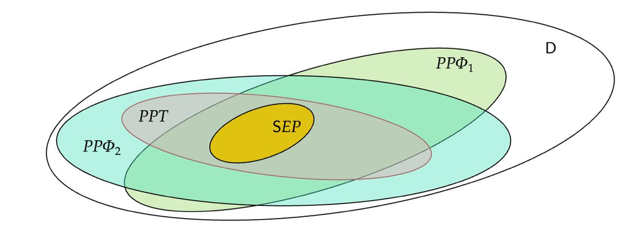

A Schematic View of $\mathsf{PP}\Phi$ and $\mathsf{SEP}$

## 5 What’s Next?

Keep in mind that the above figure is very rough and inaccurate. There are several interesting questions one can ask about it to make it more precise. For example, we may look at different PnCP maps and their corresponding $\mathsf{PP}\Phi$’s, compare their volumes, and see how they relate to each other. There is another direction we can explore, which is to get familiar with other entanglement criteria, and then compare them to those based on PnCP maps.

Back to top